# D17129392PSICAPart2RCommands

### 2.5 Inspecting continuous variables of interest

#### Total HADS Anxiety Score (anxiety)

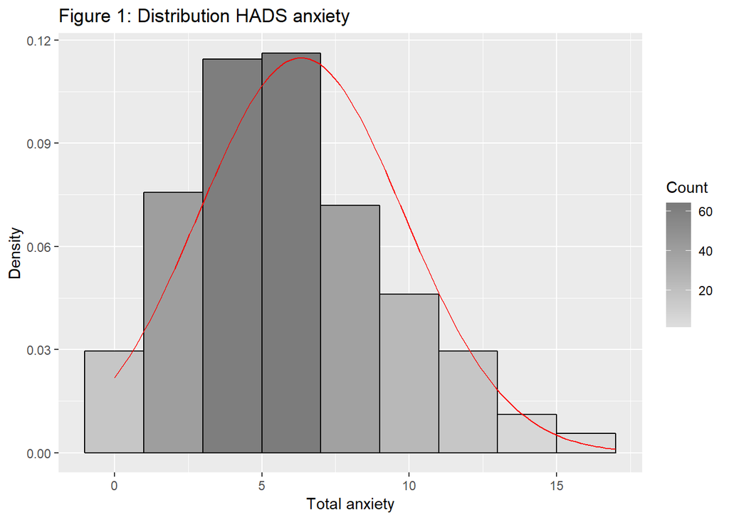

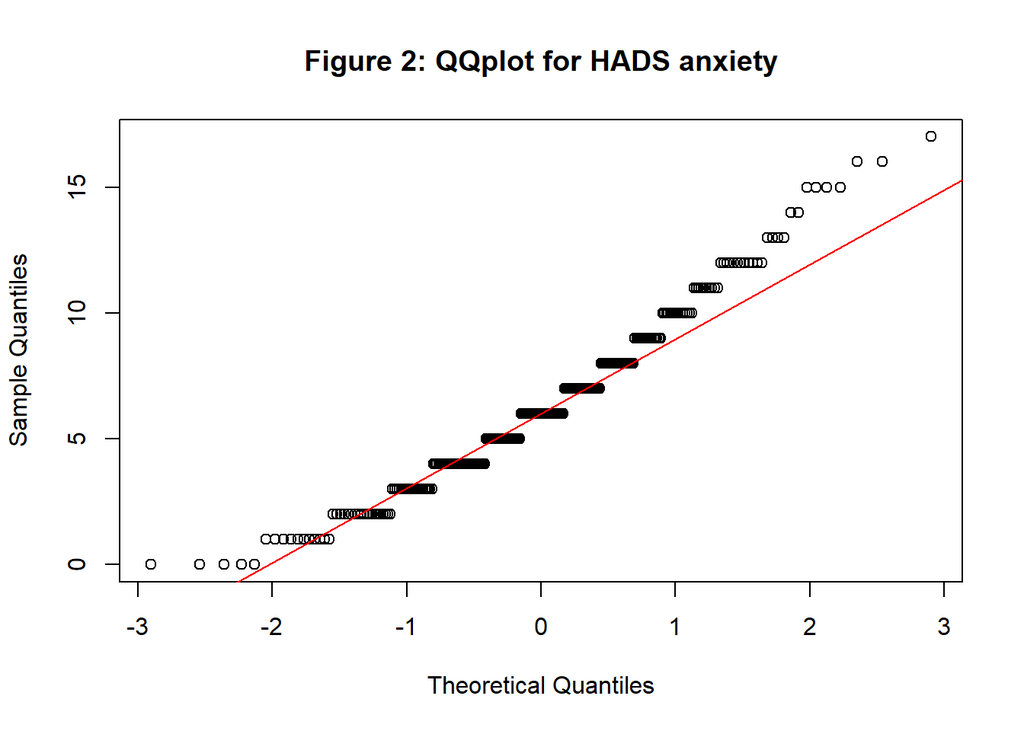

```
##
##  One-sample Kolmogorov-Smirnov test
##
## data:  sleep_dataset$anxiety
## D = 0.10636, p-value = 0.004348
## alternative hypothesis: two-sided
```

### 2.6 Total HADS Depression

#### Code for inspecting the variable

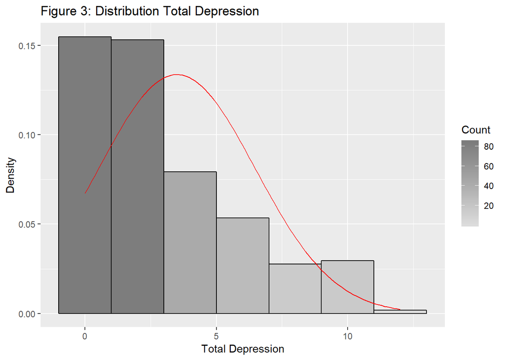

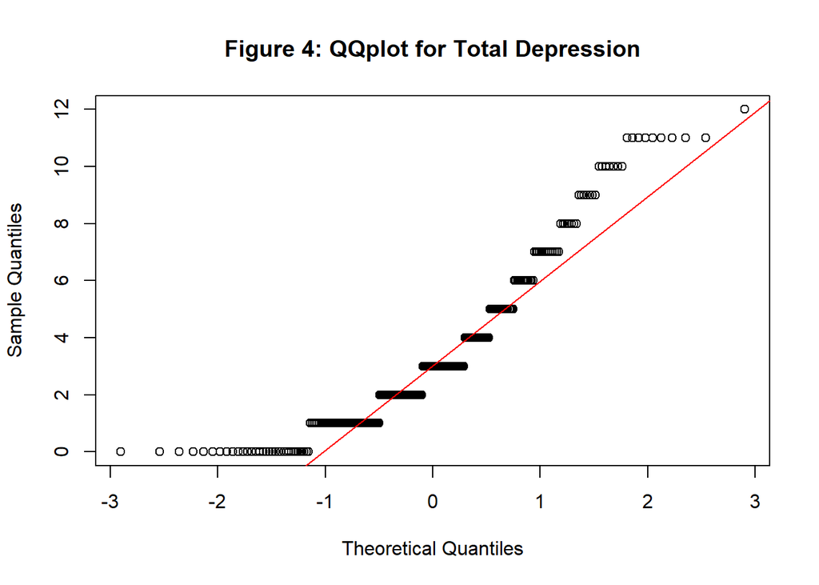

```
##
##  One-sample Kolmogorov-Smirnov test
##
## data:  sleep_dataset$depress
## D = 0.18207, p-value = 3.145e-08
## alternative hypothesis: two-sided
```

#### Report of Normality Analysis

Total HADS Depression is represented by a scale variable in the dataset. Inspection of standardized normal scores for skewness and kurtosis indicated that while both skewness and kurtosis were falling within the acceptable range of +/-2, (skewness of 0.9586748 SE=0.1487959), (kurtosis of 0.1343651 SE=0.2975918. On further inspection using plots like histogram and normality plot (figure 3 and figure 4), we found that the distribution is not normal and is positively skewed. On inspection of the count of outliers, we found only 0 or 0% standardised scores were outside the acceptable range of +/- 3.29 which implies none of the values is outside the 95% Confidence Interval.

### 2.7 Stress Indicators (stressmo+impact1)

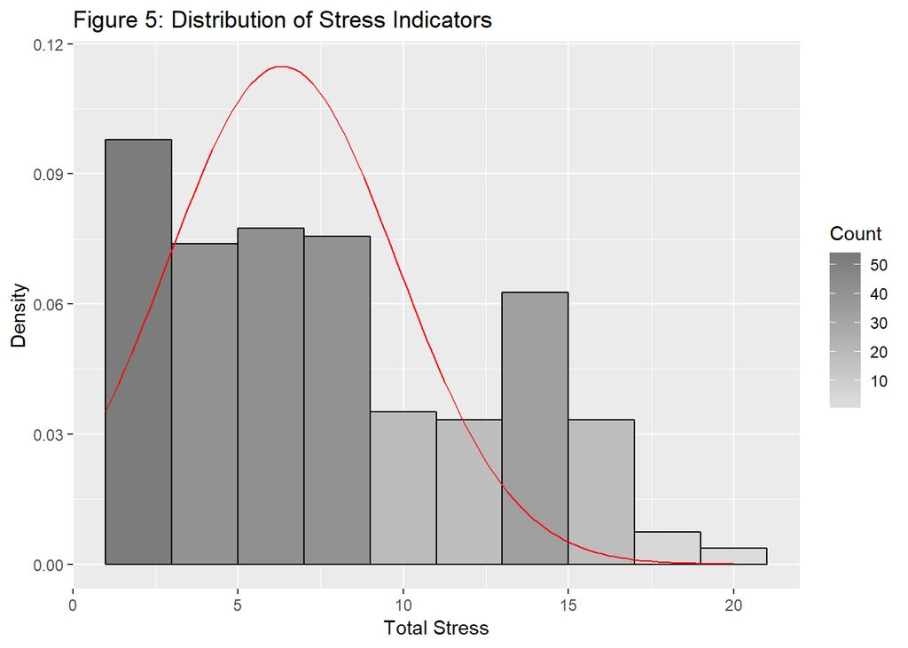

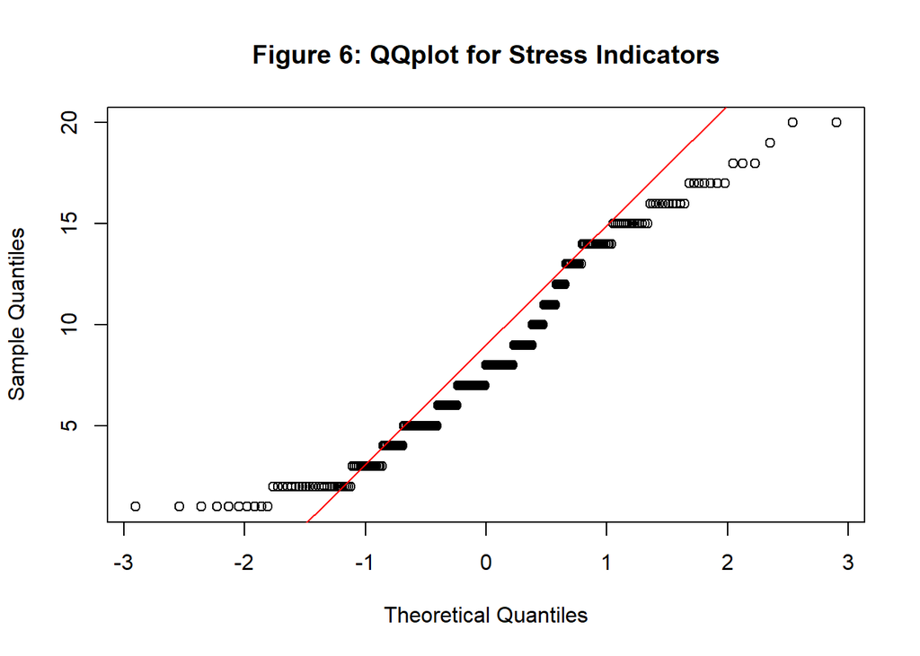

```
##
##  One-sample Kolmogorov-Smirnov test
##
## data:  sleep_dataset$stressindicators
## D = 0.11443, p-value = 0.001655
## alternative hypothesis: two-sided
```

#### Normality Analysis

A new variable stressindicators was created for the purpose of this study by adding the variables stressmo and impact1. The new variable stressindicators is a considered as a continuous variable for this study.

Inspection of the histogram and normality plot shows that the distribution is approaching a normal distribution. Inspection of standardized normal scores for skewness and kurtosis indicated that while both skewness and kurtosis were falling within the acceptable range of +/-2, (skewness of 0.3826961 SE=0.1487959), (kurtosis of -0.9184596 SE=0.2975918. Further inspection of the variable using standardized scores showed that only 0% were outside the acceptable range of +/3.29.

Further analysis of the variable with Kolmogorov-Smirnov Test normality test, we found the p-value = .002 (which is less than standard value of .05) which rejects the null hypothesis that the data is normally distributed. (The majority results of ks test is proved to be not normal and here we are not solely relying on this test for normality detection).

Hence, from above observations stressindicators will therefore be treated as normal within this analysis (md =8,n=271).